# DM_Assignment4_Duo_Zhou_Part1

Duo Zhou

8/7/2020

```r
dataPath <- "C:/Users/zd000/Desktop/MSCA/Data Mining/Assignments/week4/"
DB.train <-read.csv(paste(dataPath, 'DBtrain.csv', sep = '/'), header = TRUE)
DB.test <-read.csv(paste(dataPath, 'DBtest.csv', sep = '/'), header = TRUE)
head(DB.train)
```

```
##              race gender age admission_type_id discharge_disposition_id
## 1 AfricanAmerican      0  75                 3                        1
## 2       Caucasian      1  65                 1                        3
## 3       Caucasian      0  55                 1                        3
## 4       Caucasian      0  45                 3                        1
## 5 AfricanAmerican      0  45                 5                       25
## 6 AfricanAmerican      0  85                 1                        3
##   time_in_hospital num_lab_procedures num_procedures num_medications
## 1                2                  1              1               8
## 2                3                  1              0              25
## 3                1                 49              0              13
## 4                4                 40              5              15
## 5               11                 78              1              19
## 6                3                 38              1              15
##   number_outpatient number_emergency number_inpatient      diag_1
```

[output cut: 41 more lines]

```r
head(DB.test)
```

```
##              race gender age admission_type_id discharge_disposition_id
## 1       Caucasian      1  45                 1                        1
## 2       Caucasian      0  85                 1                        1
## 3       Caucasian      0  95                 3                        3
## 4       Caucasian      0  45                 1                        3
## 5       Caucasian      1  85                 1                        6
## 6 AfricanAmerican      0  65                 3                        1
##   time_in_hospital num_lab_procedures num_procedures num_medications
## 1                1                 51              0               8
## 2               13                 68              2              28
## 3               12                 33              3              18
## 4                7                 60              0              15
## 5               10                 55              1              31
## 6                1                 49              5               2
##   number_outpatient number_emergency number_inpatient      diag_1
```

[output cut: 41 more lines]

```r
dim(DB.train)
```

```
## [1] 48041    37
```

```r
dim(DB.test)
```

```
## [1] 20589    37
```

### Select categorical columns to covert to factors

```r
categorical_cols = c('race','admission_type_id','discharge_disposition_id','diag_1', 'max_glu_serum', 'A1Cresult', 'metformin',
     'repaglinide', 'nateglinide', 'chlorpropamide', 'glimepiride', 'glipizide', 'glyburide', 'tolbutamide',
     'pioglitazone', 'rosiglitazone', 'acarbose', 'miglitol', 'troglitazone', 'tolazamide', 'insulin', 'glyburide.metformin',
     'glipizide.metformin', 'metformin.pioglitazone','change','diabetesMed','readmitted','gender')

DB.train[,categorical_cols]<-lapply(DB.train[ ,categorical_cols],as.factor)
DB.test[,categorical_cols]<-lapply(DB.test[ ,categorical_cols],as.factor)
head(DB.train[,categorical_cols])
```

```
##              race admission_type_id discharge_disposition_id      diag_1
## 1 AfricanAmerican                 3                        1   Digestive
## 2       Caucasian                 1                        3       Other
## 3       Caucasian                 1                        3 Circulatory
## 4       Caucasian                 3                        1   Neoplasms
## 5 AfricanAmerican                 5                       25       Other
## 6 AfricanAmerican                 1                        3      Injury
##   max_glu_serum  A1Cresult metformin repaglinide nateglinide chlorpropamide
## 1    Not tested Not tested        No          No          No             No
## 2    Not tested Not tested        No          No          No             No
## 3    Not tested Not tested        No          No          No             No
## 4    Not tested Not tested        No          No          No             No
## 5    Not tested Not tested        No          No          No             No
## 6    Not tested Not tested        No          No          No             No
##   glimepiride glipizide glyburide tolbutamide pioglitazone rosiglitazone
```

[output cut: 27 more lines]

```r
head(DB.test[,categorical_cols])
```

```
##              race admission_type_id discharge_disposition_id      diag_1
## 1       Caucasian                 1                        1   Neoplasms
## 2       Caucasian                 1                        1 Circulatory
## 3       Caucasian                 3                        3 Circulatory
## 4       Caucasian                 1                        3 Circulatory
## 5       Caucasian                 1                        6 Circulatory
## 6 AfricanAmerican                 3                        1 Respiratory
##   max_glu_serum  A1Cresult metformin repaglinide nateglinide chlorpropamide
## 1    Not tested Not tested        No          No          No             No
## 2    Not tested Not tested        No          No          No             No
## 3    Not tested Not tested        No          No          No             No
## 4    Not tested Not tested    Steady          Up          No             No
## 5    Not tested Not tested        No          No          No             No
## 6    Not tested Not tested        No          No          No             No
##   glimepiride glipizide glyburide tolbutamide pioglitazone rosiglitazone
```

[output cut: 27 more lines]

Fitting the full model

```r
full.model <- glm(readmitted~.,family=binomial(link='logit'),data=DB.train)
(full.model.aic <- full.model$aic)
```

```
## [1] 61409.97
```

Using Step function with direction=both to get the model with the best AIC

```r
best.AIC.model.both<-step(glm(readmitted~.,family=binomial(link='logit'),data=DB.train)
                            ,direction="both",trace=FALSE)
```

```r
summary(best.AIC.model.both)
```

```
##
## Call:
## glm(formula = readmitted ~ race + gender + age + admission_type_id +
##     discharge_disposition_id + time_in_hospital + num_lab_procedures +
##     num_procedures + num_medications + number_outpatient + number_emergency +
##     number_inpatient + diag_1 + number_diagnoses + A1Cresult +
##     metformin + chlorpropamide + glipizide + rosiglitazone +
##     acarbose + insulin + diabetesMed, family = binomial(link = "logit"),
##     data = DB.train)
##
## Deviance Residuals:
##    Min      1Q  Median      3Q     Max
## -4.475  -1.006  -0.816   1.248   2.734
##
## Coefficients:
##                              Estimate Std. Error z value Pr(>|z|)
## (Intercept)                -2.218e+00  3.630e-01  -6.109 1.00e-09 ***
## raceAsian                  -5.602e-01  1.254e-01  -4.467 7.95e-06 ***
## raceCaucasian               2.740e-02  2.595e-02   1.056 0.290947
## raceHispanic               -1.989e-01  7.156e-02  -2.779 0.005456 **
## raceOther                  -3.052e-01  7.949e-02  -3.840 0.000123 ***
## gender1                    -5.335e-02  1.959e-02  -2.723 0.006463 **
## age                         5.178e-03  7.126e-04   7.265 3.72e-13 ***
## admission_type_id3         -1.339e-01  2.795e-02  -4.793 1.65e-06 ***
## admission_type_id4          1.616e+00  1.185e+00   1.364 0.172569
## admission_type_id5          2.211e-01  3.251e-02   6.801 1.04e-11 ***
## discharge_disposition_id2   5.300e-05  6.622e-02   0.001 0.999361
## discharge_disposition_id3  -1.495e-02  3.276e-02  -0.456 0.648183
## discharge_disposition_id4  -9.223e-02  1.140e-01  -0.809 0.418628
## discharge_disposition_id5   2.054e-01  8.409e-02   2.443 0.014579 *
## discharge_disposition_id6   1.465e-01  3.156e-02   4.641 3.47e-06 ***
## discharge_disposition_id7  -8.186e-02  1.300e-01  -0.630 0.528878
## discharge_disposition_id8   3.087e-01  2.880e-01   1.072 0.283693
## discharge_disposition_id9  -1.037e-01  9.211e-01  -0.113 0.910377
## discharge_disposition_id10  7.618e-01  8.867e-01   0.859 0.390238
## discharge_disposition_id11 -1.540e+01  5.133e+01  -0.300 0.764140
## discharge_disposition_id12  4.346e-01  1.415e+00   0.307 0.758715
## discharge_disposition_id13 -2.290e+00  2.971e-01  -7.708 1.28e-14 ***
## discharge_disposition_id14 -2.570e+00  3.263e-01  -7.877 3.34e-15 ***
## discharge_disposition_id15  1.563e+00  4.670e-01   3.347 0.000817 ***
```

[output cut: 41 more lines]

```
## acarboseUp                  1.920e+00  1.123e+00   1.709 0.087417 .
## insulinNo                  -4.300e-02  3.722e-02  -1.155 0.247896
## insulinSteady              -1.510e-01  3.451e-02  -4.375 1.21e-05 ***
## insulinUp                  -5.658e-02  4.234e-02  -1.336 0.181388
## diabetesMed1                3.315e-01  3.142e-02  10.552  < 2e-16 ***
## ---
## Signif. codes:  0 '***' 0.001 '**' 0.01 '*' 0.05 '.' 0.1 ' ' 1
##
## (Dispersion parameter for binomial family taken to be 1)
##
##     Null deviance: 64859  on 48040  degrees of freedom
## Residual deviance: 61249  on 47971  degrees of freedom
## AIC: 61389
##
## Number of Fisher Scoring iterations: 14
```

We need to find the best Threshold value for the model, let us first take a look at the ROC curve.

```r
library(AUC)
```

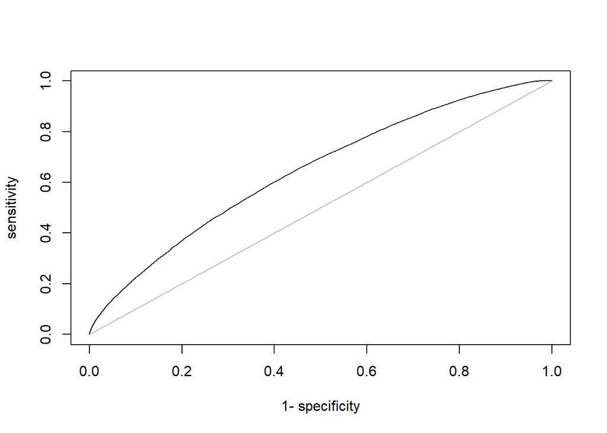

```r
plot(roc(best.AIC.model.both$fitted.values,DB.train$readmitted))
```

```r
auc(roc(best.AIC.model.both$fitted.values,DB.train$readmitted))
```

```
## [1] 0.645865
```

It is hard to find the best TP/FP point from the ROC curve. Let us calculate the TP/FP ratio and accuracy at different threhold values. Threshold values are chosen bewteen 0.05 to 0.95 with an increment of 0.05.

```r
library(caret)
TP<-c()
FP<-c()
TPoverFP<-c()
th<-c()
accu<-c()
for(threshold in seq(0.05,0.95,0.05)){
xp = best.AIC.model.both$fitted.values
xp[xp >= threshold] = 1
xp[xp <  threshold] = 0
xp<-as.factor(xp)
cm<-confusionMatrix(data=xp,reference=DB.train$readmitted)
TP<-c(TP,as.numeric(cm$byClass[1]))
FP<-c(FP,(1-as.numeric(cm$byClass[2])))
TPoverFP<-c(TPoverFP,as.numeric(cm$byClass[1])/(1-as.numeric(cm$byClass[2])))
th<-c(th,threshold)
accu<-c(accu,as.numeric(cm$overall[1]))
}



cbind(th=th,accuracy=accu,TP=TP,FP=FP,TPoverFP=TPoverFP)
```

```
##         th  accuracy         TP           FP   TPoverFP
##  [1,] 0.05 0.4221394 0.02869340 0.0001541386 186.153218
##  [2,] 0.10 0.4256573 0.03513192 0.0009248317  37.987364
##  [3,] 0.15 0.4266356 0.03702149 0.0012844885  28.821967
##  [4,] 0.20 0.4315689 0.04723913 0.0041103633  11.492691
##  [5,] 0.25 0.4513645 0.09262370 0.0218876843   4.231772
##  [6,] 0.30 0.4963052 0.20715235 0.0791244926   2.618056
##  [7,] 0.35 0.5512167 0.38641612 0.2068026512   1.868526
##  [8,] 0.40 0.5987594 0.59118903 0.3901248523   1.515384
##  [9,] 0.45 0.6237172 0.76768843 0.5876791861   1.306305
## [10,] 0.50 0.6266939 0.87735321 0.7413553923   1.183445
## [11,] 0.55 0.6222602 0.93729442 0.8403123876   1.115412
## [12,] 0.60 0.6168897 0.96721254 0.8974978164   1.077677
## [13,] 0.65 0.6113528 0.98222409 0.9332065971   1.052526
## [14,] 0.70 0.6071481 0.99009728 0.9551456610   1.036593
## [15,] 0.75 0.6034845 0.99419134 0.9701998664   1.024728
## [16,] 0.80 0.6005495 0.99688572 0.9814006063   1.015779
## [17,] 0.85 0.5986969 0.99853034 0.9883882238   1.010261
## [18,] 0.90 0.5971982 0.99944013 0.9934234188   1.006057
## [19,] 0.95 0.5958660 0.99986003 0.9973282639   1.002539
```

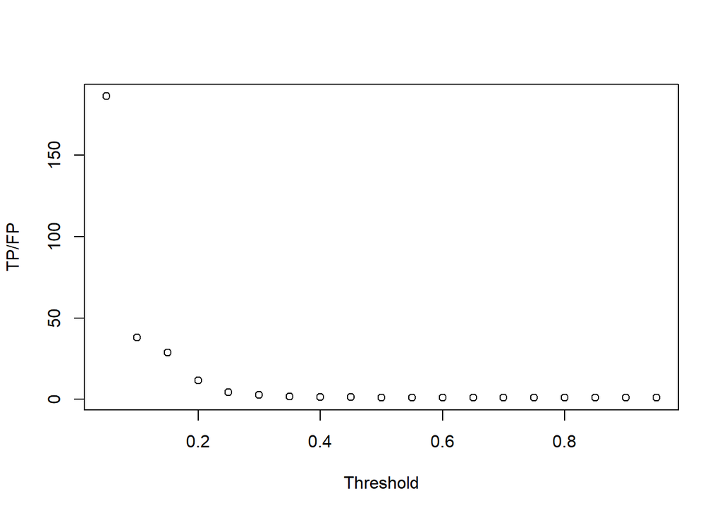

```r
plot(th,TPoverFP,xlab='Threshold',ylab='TP/FP')
```

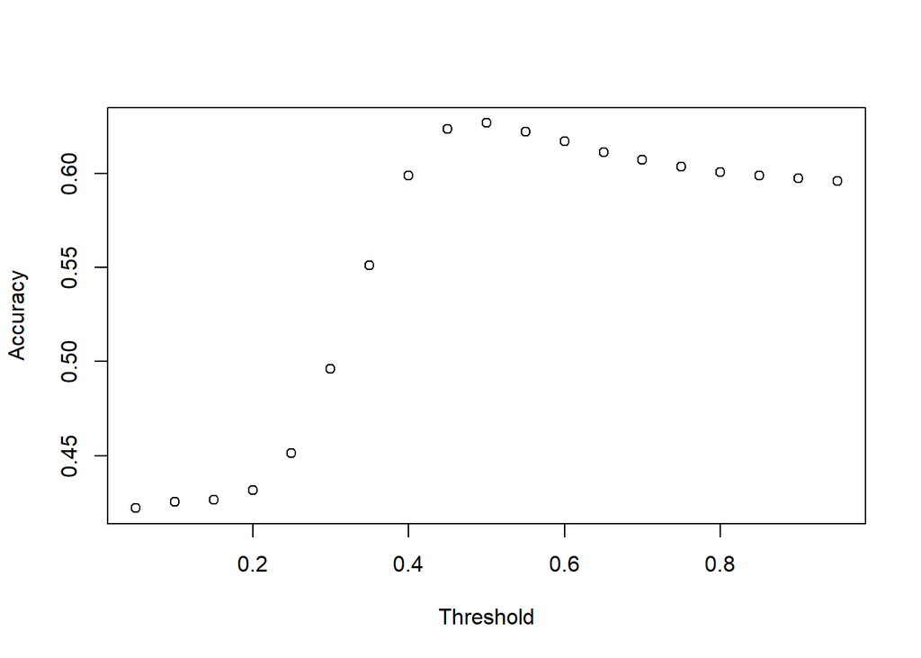

```r
plot(th,accu,xlab='Threshold',ylab='Accuracy')
```

From the table above, we can see that the TP/FP value decreases as threshold increases. In this case, Accuracy is a better measurement for picking the best threshold value. The accuracy is highest(0.627), when threshold is 0.5.

Let’s construct the Confusion Matrix using Threshold = 0.5.

```r
xp = best.AIC.model.both$fitted.values
xp[xp >= 0.5] = 1
xp[xp <  0.5] = 0
xp<-as.factor(xp)
confusionMatrix(xp,DB.train$readmitted)
```

```
## Confusion Matrix and Statistics
##
##           Reference
## Prediction     0     1
##          0 25073 14429
##          1  3505  5034
##
##                Accuracy : 0.6267
##                  95% CI : (0.6224, 0.631)
##     No Information Rate : 0.5949
##     P-Value [Acc > NIR] : < 2.2e-16
##
##                   Kappa : 0.1494
##
##  Mcnemar's Test P-Value : < 2.2e-16
##
##             Sensitivity : 0.8774
##             Specificity : 0.2586
##          Pos Pred Value : 0.6347
##          Neg Pred Value : 0.5895
##              Prevalence : 0.5949
##          Detection Rate : 0.5219
##    Detection Prevalence : 0.8223
##       Balanced Accuracy : 0.5680
##
##        'Positive' Class : 0
##
```

Based on the Confusion Matrix, we can see that with Threshold=0.5, the accuracy is 0.6267 and sensitivity(TP) is 0.8774. Note that the False Positive(1-Specificity) is also very high(0.741).

Performing holdout validation using test data

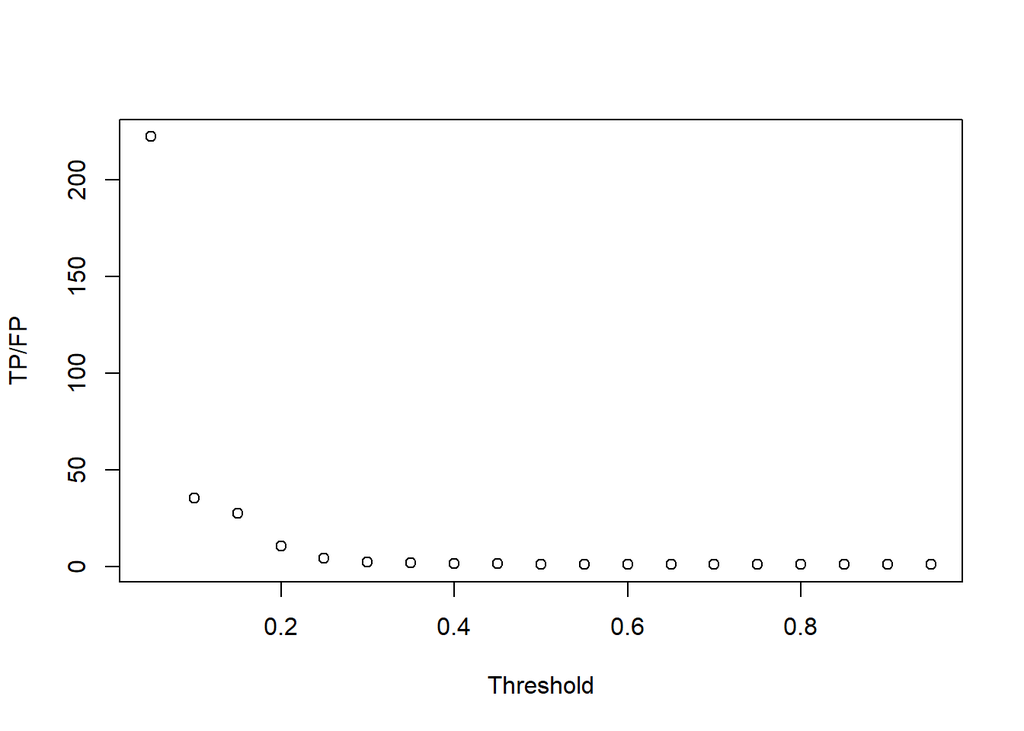

```r
fitted.results <- predict(best.AIC.model.both,
                          newdata=DB.test,type='response')

#library(caret)
TP<-c()
FP<-c()
TPoverFP<-c()
th<-c()
accu<-c()
for(threshold in seq(0.05,0.95,0.05)){
xp1<-fitted.results
xp1[xp1 >= threshold] = 1
xp1[xp1 <  threshold] = 0
xp1<-as.factor(xp1)
cm<-confusionMatrix(data=xp1,reference=DB.test$readmitted)
TP<-c(TP,as.numeric(cm$byClass[1]))
FP<-c(FP,(1-as.numeric(cm$byClass[2])))
TPoverFP<-c(TPoverFP,as.numeric(cm$byClass[1])/(1-as.numeric(cm$byClass[2])))
th<-c(th,threshold)
accu<-c(accu,as.numeric(cm$overall[1]))
}

plot(th,TPoverFP,xlab='Threshold',ylab='TP/FP')
```

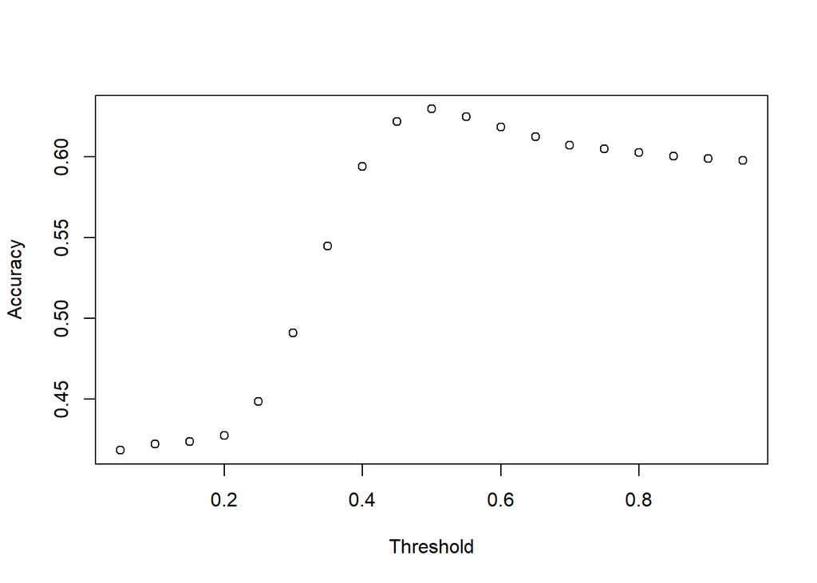

```r
plot(th,accu,xlab='Threshold',ylab='Accuracy')
```

```r
cbind(th=th,accuracy=accu,TP=TP,FP=FP,TPoverFP=TPoverFP)
```

```
##         th  accuracy         TP           FP   TPoverFP
##  [1,] 0.05 0.4184759 0.02682491 0.0001206709 222.298000
##  [2,] 0.10 0.4224586 0.03405950 0.0009653674  35.281387
##  [3,] 0.15 0.4237214 0.03641684 0.0013273802  27.435125
##  [4,] 0.20 0.4275098 0.04470818 0.0042234826  10.585619
##  [5,] 0.25 0.4486376 0.09250528 0.0226861349   4.077613
##  [6,] 0.30 0.4911846 0.20760852 0.0878484373   2.363258
##  [7,] 0.35 0.5449026 0.38091367 0.2116568119   1.799676
##  [8,] 0.40 0.5942494 0.58762803 0.3959213226   1.484204
##  [9,] 0.45 0.6219826 0.76345310 0.5880294437   1.298325
## [10,] 0.50 0.6296566 0.87693058 0.7374200555   1.189187
## [11,] 0.55 0.6249939 0.93529507 0.8356461928   1.119248
## [12,] 0.60 0.6185827 0.96602179 0.8971883673   1.076721
## [13,] 0.65 0.6126087 0.97894651 0.9312175697   1.051254
## [14,] 0.70 0.6071203 0.98691270 0.9566791360   1.031603
## [15,] 0.75 0.6051775 0.99333442 0.9710389767   1.022960
## [16,] 0.80 0.6028462 0.99601691 0.9808133221   1.015501
## [17,] 0.85 0.6005634 0.99772395 0.9890189453   1.008802
## [18,] 0.90 0.5991063 0.99845554 0.9937251116   1.004760
## [19,] 0.95 0.5979892 0.99918712 0.9975865814   1.001604
```

```r
xp1 = fitted.results
xp1[xp1 >= 0.5] = 1
xp1[xp1 <  0.5] = 0
xp1<-as.factor(xp1)
confusionMatrix(data=xp1,reference=DB.test$readmitted)
```

```
## Confusion Matrix and Statistics
##
##           Reference
## Prediction     0     1
##          0 10788  6111
##          1  1514  2176
##
##                Accuracy : 0.6297
##                  95% CI : (0.623, 0.6363)
##     No Information Rate : 0.5975
##     P-Value [Acc > NIR] : < 2.2e-16
##
##                   Kappa : 0.1534
##
##  Mcnemar's Test P-Value : < 2.2e-16
##
##             Sensitivity : 0.8769
##             Specificity : 0.2626
##          Pos Pred Value : 0.6384
##          Neg Pred Value : 0.5897
##              Prevalence : 0.5975
##          Detection Rate : 0.5240
##    Detection Prevalence : 0.8208
##       Balanced Accuracy : 0.5698
##
##        'Positive' Class : 0
##
```

Based on the Confusion Matrix, we can see that with Threshold=0.5, the accuracy is 0.6297, sensitivity(TP) is 0.8769 and the False Positive(1-Specificity) is still very high(0.737). The result is very similar to training data fit which indicates a good stability of our model. Holdout validation is a success.

Gain Chart

```r
library(gains)
gains(as.numeric(DB.test$readmitted)-1,fitted.results,10)
```

```
## Depth                            Cume   Cume Pct                     Mean
##  of           Cume     Mean      Mean   of Total    Lift   Cume     Model
## File     N      N      Resp      Resp      Resp    Index   Lift     Score
## -------------------------------------------------------------------------
##   10  2058   2058      0.63      0.63      15.7%     158    158      0.66
##   20  2059   4117      0.52      0.58      28.7%     130    144      0.52
##   30  2059   6176      0.47      0.54      40.4%     117    135      0.47
##   40  2059   8235      0.44      0.52      51.3%     109    128      0.44
##   50  2059  10294      0.41      0.50      61.6%     103    123      0.41
##   60  2059  12353      0.40      0.48      71.5%      99    119      0.39
##   70  2059  14412      0.33      0.46      79.8%      83    114      0.36
##   80  2059  16471      0.34      0.44      88.3%      85    110      0.33
##   90  2059  18530      0.28      0.43      95.3%      71    106      0.30
##  100  2059  20589      0.19      0.40     100.0%      47    100      0.19
```

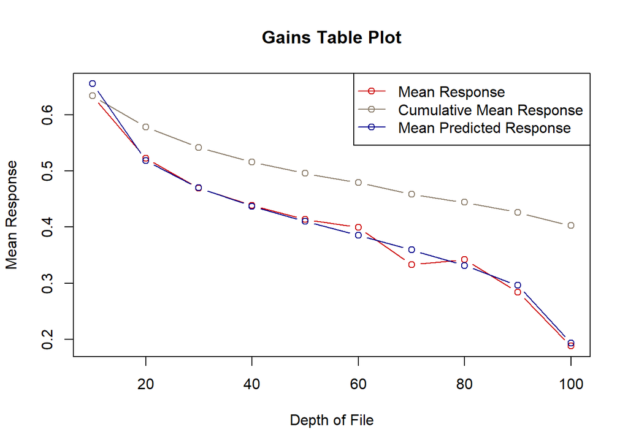

```r
plot(gains(as.numeric(DB.test$readmitted)-1,fitted.results,10))
```

ROC Curve

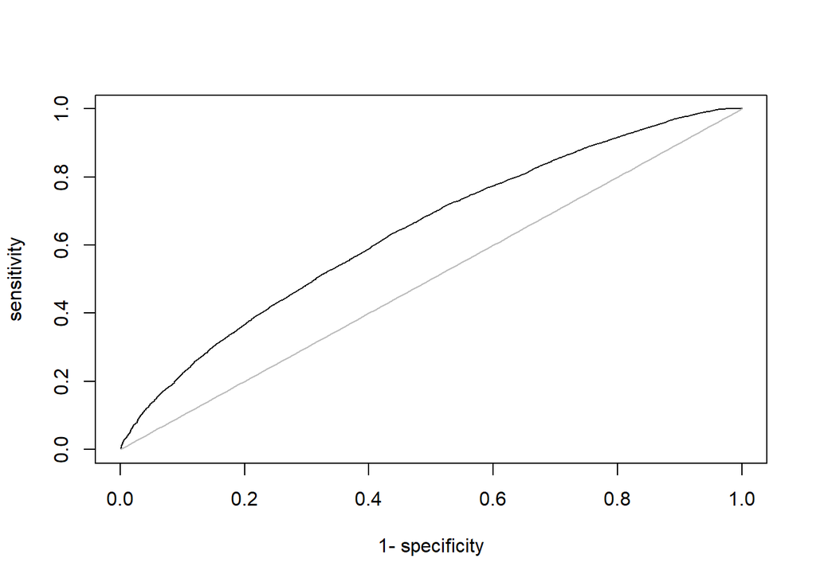

```r
library(AUC)
plot(roc(fitted.results,DB.test$readmitted))
```

```r
auc(roc(fitted.results,DB.test$readmitted))
```

```
## [1] 0.6404412
```